# Diastolic blood pressure in adults aged 30 and over in Bharatpur, Nepal

Dataset 3: Nepal hypertension and cardiovascular risk-factor survey

RSR feasibility analysis

2026-08-03

# Introduction

This is a community-based cross-sectional survey of adults aged 30 years and over living in Bharatpur, Chitwan district, Nepal, designed to estimate the prevalence of hypertension and describe its behavioural and anthropometric correlates (Dhungana and colleagues, *PLOS ONE* 2016, e0185806). Blood pressure was measured twice with a digital device and averaged, and the WHO STEPS instrument was used for tobacco, alcohol, diet and physical activity, with height and weight measured directly. Diastolic pressure is analysed separately from systolic here because the two behave differently with age – diastolic pressure plateaus and then falls in later life as arteries stiffen, whereas systolic pressure keeps rising – so the same predictor set can give a noticeably different picture.

**Aim.** Among adults aged 30 and over in Bharatpur, we examined which of sex, age band, education, occupation, poverty, smoking, smokeless tobacco, alcohol, fruit and vegetable intake, salt intake, physical activity, family history of hypertension and body mass index are independently associated with mean diastolic blood pressure, mutually adjusting for the others.

This is a *Purpose 3* analysis: several predictors are of interest and the question is which remain associated with the outcome after mutual adjustment.

# Methods

**Data source.** A cross-sectional survey of 1159 adults aged 30 years and over resident in Bharatpur Municipality, Chitwan, Nepal. The source study used multistage cluster sampling: four wards were selected at random and approximately 300 participants enrolled in each, with the sample size calculation assuming a design effect of 1.5. **The ward identifier is absent from this extract**, with direct consequences for the standard errors (see Limitations). Each row is one participant.

**Variables.** The outcome is `diastolic_bp`, the mean of two diastolic readings in mmHg. Predictors are sex (reference *Female*); age band in years (reference *30-39*; age was recorded only in four bands, so a per-year effect cannot be estimated); education (reference *None or informal*); main occupation (reference *Household work*); family income per head below the poverty line (reference *No*); smoking status (reference *Never*); current smokeless tobacco use (reference *No*); any alcohol in the last month (reference *No*); fruit and vegetable servings per day; estimated salt intake in g/day; physical activity level (reference *Moderate or high*); family history of hypertension (reference *No*); and body mass index in kg/m2.

Systolic pressure is deliberately **not** a predictor. It is measured on the same occasion, on the same arm, from the same physiology, and correlates with diastolic at r = 0.79; including it would produce a large, meaningless coefficient and drive every other estimate to zero. For the same reason `hypertension`, `bp_awareness` and `antihypertensive_drug` are excluded: `hypertension` is defined as raised measured pressure *or* current treatment, so it is a function of the outcome, and the other two are consequences of having been found hypertensive in the past. Two further pairs measure the same construct twice and only one member of each may enter: `physical_activity` is a deterministic cut of `mets_min_per_week` at 600 MET-minutes per week (the “Low” group spans 0-600, “Moderate or high” spans 620-29,260) and the categorical version is used because it is the WHO STEPS classification reported in the source paper; and `cigarettes_per_week` is zero for every never-smoker, so `smoking_status` is used instead because it distinguishes former from never smokers.

**Statistical analysis.** Linear regression via `lm()`, justified because the outcome is continuous. We fitted a univariable model for each predictor first, then a single multivariable model containing all of them. Predictors were chosen in advance on subject-matter grounds, not by significance. Significance threshold 0.05; estimates are reported with 95% confidence intervals. Assumptions were checked with `performance::check_model()`, and because non-constant error variance was flagged, HC3 heteroscedasticity-consistent standard errors are reported alongside the ordinary ones. Analysis used R version 4.6.0 (2026-04-24) with tidyverse, gtsummary, performance and sandwich.

**Missing data.** Complete-case analysis: 1159 of 1159 rows were analysed (0 dropped). Every variable in this file is 100% complete, so listwise deletion removes no rows at all. There is no missing-data story here: no imputation is required and complete-case selection bias cannot arise.

# Results

## Sample characteristics

**Table 1. Sample characteristics.**

| **Characteristic** | **N** | **N = 1,159**<sup>1</sup> |
| --- | --- | --- |
| Diastolic blood pressure (mmHg) | 1,159 | 80 (70, 90) |
| Sex | 1,159 |  |
| Female |  | 824 (71%) |
| Male |  | 335 (29%) |
| Age band (years) | 1,159 |  |
| 30-39 |  | 383 (33%) |
| 40-49 |  | 295 (25%) |
| 50-59 |  | 218 (19%) |
| 60 or more |  | 263 (23%) |
| Education | 1,159 |  |
| None or informal |  | 626 (54%) |
| Primary |  | 136 (12%) |
| Secondary |  | 239 (21%) |
| Higher |  | 158 (14%) |
| Main occupation | 1,159 |  |
| Household work |  | 659 (57%) |
| Agriculture or labour |  | 142 (12%) |
| Job or self-employed |  | 305 (26%) |
| Unemployed |  | 53 (4.6%) |
| Below poverty line | 1,159 | 316 (27%) |
| Smoking status | 1,159 |  |
| Never |  | 770 (66%) |
| Former |  | 180 (16%) |
| Current |  | 209 (18%) |
| Smokeless tobacco use | 1,159 | 139 (12%) |
| Alcohol in the last month | 1,159 | 177 (15%) |
| Fruit and vegetable servings per day | 1,159 | 2.29 (1.43, 3.14) |
| Salt intake (g/day) | 1,159 | 2.85 (1.90, 4.55) |
| Physical activity level | 1,159 |  |
| Moderate or high |  | 744 (64%) |
| Low |  | 415 (36%) |
| Family history of hypertension | 1,159 | 170 (15%) |
| Body mass index (kg/m2) | 1,159 | 23.6 (21.0, 26.4) |

<sup>1</sup> Median (Q1, Q3); n (%)

Mean diastolic pressure was 80.9 mmHg (SD 12.4), a much narrower distribution than the systolic one. The sample is 71.1% female, 35.8% are classified as physically inactive, and 131 participants (11.3%) were on antihypertensive medication when measured. Their mean diastolic pressure was 87.4 mmHg against 80 mmHg in the untreated – a gap of 7.4 mmHg that exists *despite* treatment and therefore understates the underlying difference.

## Exploratory figure

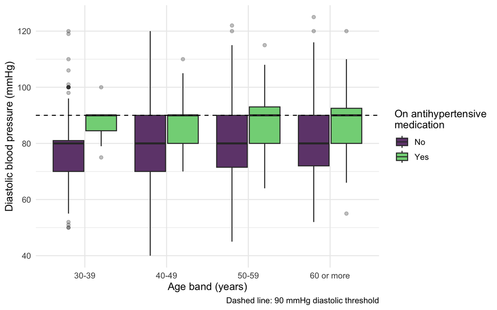

Figure 2. Diastolic blood pressure by age band, separately for participants taking and not taking antihypertensive medication. The dashed line marks the 90 mmHg threshold.

## Univariable models

| **Characteristic** | **N** | **Beta** | **95% CI** | **p-value** |
| --- | --- | --- | --- | --- |
| Sex | 1,159 |  |  |  |
| Female |  | — | — |  |
| Male |  | 4.2 | 2.7, 5.8 | <0.001 |
| Age band (years) | 1,159 |  |  |  |
| 30-39 |  | — | — |  |
| 40-49 |  | 3.2 | 1.3, 5.0 | <0.001 |
| 50-59 |  | 4.6 | 2.6, 6.7 | <0.001 |
| 60 or more |  | 5.9 | 3.9, 7.8 | <0.001 |
| Education | 1,159 |  |  |  |
| None or informal |  | — | — |  |
| Primary |  | -1.3 | -3.6, 0.96 | 0.3 |
| Secondary |  | -1.5 | -3.4, 0.31 | 0.10 |
| Higher |  | -0.62 | -2.8, 1.6 | 0.6 |
| Main occupation | 1,159 |  |  |  |
| Household work |  | — | — |  |
| Agriculture or labour |  | 0.74 | -1.5, 3.0 | 0.5 |
| Job or self-employed |  | 2.9 | 1.2, 4.6 | <0.001 |
| Unemployed |  | 4.8 | 1.3, 8.2 | 0.007 |
| Below poverty line | 1,159 |  |  |  |
| No |  | — | — |  |
| Yes |  | 0.88 | -0.72, 2.5 | 0.3 |
| Smoking status | 1,159 |  |  |  |
| Never |  | — | — |  |
| Former |  | 7.2 | 5.2, 9.1 | <0.001 |
| Current |  | 2.2 | 0.30, 4.0 | 0.023 |
| Smokeless tobacco use | 1,159 |  |  |  |
| No |  | — | — |  |
| Yes |  | 3.7 | 1.5, 5.9 | <0.001 |
| Alcohol in the last month | 1,159 |  |  |  |
| No |  | — | — |  |
| Yes |  | 5.1 | 3.1, 7.0 | <0.001 |
| Fruit and vegetable servings per day | 1,159 | 0.41 | -0.16, 0.98 | 0.2 |
| Salt intake (g/day) | 1,159 | -0.09 | -0.40, 0.23 | 0.6 |
| Physical activity level | 1,159 |  |  |  |
| Moderate or high |  | — | — |  |
| Low |  | 2.0 | 0.51, 3.5 | 0.008 |
| Family history of hypertension | 1,159 |  |  |  |
| No |  | — | — |  |
| Yes |  | 1.4 | -0.63, 3.4 | 0.2 |
| Body mass index (kg/m2) | 1,159 | 0.86 | 0.70, 1.0 | <0.001 |

Abbreviation: CI = Confidence Interval

## Why adjustment is needed

Almost every crude estimate above is contaminated by two variables in this dataset. **Age band** is the first. It is associated with diastolic pressure and simultaneously with practically every exposure here: former smokers are concentrated in the older bands (quitting is an older person’s behaviour), 209 of the 263 participants aged 60 or more have no or informal schooling against 114 of 383 among the 30-39 year olds, and occupation shifts from paid employment towards household work and unemployment with age. A crude coefficient for education or occupation therefore contains an age effect. **Sex** is the second and is even starker here, because tobacco and alcohol in this population are overwhelmingly male behaviours: 35% of men are current smokers against 11% of women, and men have higher diastolic pressure regardless. The crude smokeless tobacco and alcohol coefficients are therefore partly measuring maleness. **Body mass index** is the third: it is the strongest single predictor of diastolic pressure in the file and it varies systematically across occupation, poverty and smoking groups (smokers are leaner), so omitting it lets those coefficients absorb an adiposity effect – sometimes in the wrong direction. Mutual adjustment is what separates these three overlapping gradients from the behaviours of interest.

## Multivariable model

| **Characteristic** | **Beta** | **95% CI** | **p-value** |
| --- | --- | --- | --- |
| Sex |  |  |  |
| Female | — | — |  |
| Male | 2.2 | 0.22, 4.1 | 0.029 |
| Age band (years) |  |  |  |
| 30-39 | — | — |  |
| 40-49 | 2.4 | 0.65, 4.2 | 0.008 |
| 50-59 | 3.7 | 1.6, 5.7 | <0.001 |
| 60 or more | 5.2 | 3.1, 7.3 | <0.001 |
| Education |  |  |  |
| None or informal | — | — |  |
| Primary | -0.91 | -3.2, 1.3 | 0.4 |
| Secondary | -0.53 | -2.4, 1.4 | 0.6 |
| Higher | -0.36 | -2.7, 2.0 | 0.8 |
| Main occupation |  |  |  |
| Household work | — | — |  |
| Agriculture or labour | -0.76 | -3.0, 1.4 | 0.5 |
| Job or self-employed | 1.5 | -0.27, 3.3 | 0.10 |
| Unemployed | 2.6 | -0.69, 5.9 | 0.12 |
| Below poverty line |  |  |  |
| No | — | — |  |
| Yes | 0.85 | -0.67, 2.4 | 0.3 |
| Smoking status |  |  |  |
| Never | — | — |  |
| Former | 5.0 | 3.1, 6.9 | <0.001 |
| Current | 0.31 | -1.7, 2.3 | 0.8 |
| Smokeless tobacco use |  |  |  |
| No | — | — |  |
| Yes | 1.5 | -0.91, 3.9 | 0.2 |
| Alcohol in the last month |  |  |  |
| No | — | — |  |
| Yes | 2.8 | 0.62, 4.9 | 0.012 |
| Fruit and vegetable servings per day | 0.34 | -0.19, 0.87 | 0.2 |
| Salt intake (g/day) | 0.08 | -0.21, 0.37 | 0.6 |
| Physical activity level |  |  |  |
| Moderate or high | — | — |  |
| Low | 0.68 | -0.71, 2.1 | 0.3 |
| Family history of hypertension |  |  |  |
| No | — | — |  |
| Yes | -0.16 | -2.0, 1.7 | 0.9 |
| Body mass index (kg/m2) | 0.94 | 0.78, 1.1 | <0.001 |

Abbreviation: CI = Confidence Interval

Model fit

| Statistic | Value |
| --- | --- |
| R-squared | 0.192 |
| Adjusted R-squared | 0.178 |
| Residual SD (mmHg) | 11.250 |
| Observations | 1159.000 |
| Model parameters (incl. intercept) | 21.000 |
| Observations per parameter | 55.200 |

The model explains 19.2% of the variance in diastolic pressure (adjusted R-squared 0.178), a little better than the corresponding systolic model but still leaving the great majority unexplained. With 1159 observations and 21 parameters there are 55.2 observations per parameter, so overfitting is not a concern. Conditional on the other twelve predictors, each additional kg/m2 of BMI is associated with a 0.94 mmHg higher diastolic pressure (95% CI 0.78 to 1.1); participants aged 60 or more average 5.2 mmHg above the 30-39 band (95% CI 3.1 to 7.3); men average 2.2 mmHg above women (95% CI 0.2 to 4.1, p = 0.029); and recent drinkers average 2.8 mmHg above non-drinkers (95% CI 0.6 to 4.9).

As in the systolic model, the smoking coefficients are the wrong way round for a causal reading: former smokers are 5 mmHg above never-smokers (95% CI 3.1 to 6.9) while current smokers are indistinguishable from never-smokers (0.3 mmHg, 95% CI -1.7 to 2.3). The natural explanation is reverse causation: in a cross-sectional survey “former smoker” partly identifies people who quit *after* being told they had a cardiovascular problem. Salt intake remains null (0.08 mmHg per g/day, 95% CI -0.21 to 0.37), as does family history (-0.2 mmHg).

### Sensitivity analysis: excluding treated participants

Adjusted estimates (mmHg, 95% CI)

All n = 1159; untreated n = 1028

| Term | All participants | Untreated only |
| --- | --- | --- |
| BMI (per kg/m2) | 0.94 (0.78 to 1.10) | 0.97 (0.80 to 1.14) |
| Age 60+ vs 30-39 | 5.22 (3.13 to 7.31) | 4.98 (2.73 to 7.24) |
| Male vs female | 2.15 (0.22 to 4.09) | 2.57 (0.51 to 4.62) |
| Alcohol last month | 2.78 (0.62 to 4.95) | 3.06 (0.72 to 5.40) |

## Unadjusted versus adjusted

**Table 2. Unadjusted and adjusted estimates.**

| **Characteristic** | **Unadjusted** **N** | **Unadjusted** **Beta** | **Unadjusted** **95% CI** | **Unadjusted** **p-value** | **Adjusted** **Beta** | **Adjusted** **95% CI** | **Adjusted** **p-value** |
| --- | --- | --- | --- | --- | --- | --- | --- |
| Sex | 1,159 |  |  |  |  |  |  |
| Female |  | — | — |  | — | — |  |
| Male |  | 4.2 | 2.7, 5.8 | <0.001 | 2.2 | 0.22, 4.1 | 0.029 |
| Age band (years) | 1,159 |  |  |  |  |  |  |
| 30-39 |  | — | — |  | — | — |  |
| 40-49 |  | 3.2 | 1.3, 5.0 | <0.001 | 2.4 | 0.65, 4.2 | 0.008 |
| 50-59 |  | 4.6 | 2.6, 6.7 | <0.001 | 3.7 | 1.6, 5.7 | <0.001 |
| 60 or more |  | 5.9 | 3.9, 7.8 | <0.001 | 5.2 | 3.1, 7.3 | <0.001 |
| Education | 1,159 |  |  |  |  |  |  |
| None or informal |  | — | — |  | — | — |  |
| Primary |  | -1.3 | -3.6, 0.96 | 0.3 | -0.91 | -3.2, 1.3 | 0.4 |
| Secondary |  | -1.5 | -3.4, 0.31 | 0.10 | -0.53 | -2.4, 1.4 | 0.6 |
| Higher |  | -0.62 | -2.8, 1.6 | 0.6 | -0.36 | -2.7, 2.0 | 0.8 |
| Main occupation | 1,159 |  |  |  |  |  |  |
| Household work |  | — | — |  | — | — |  |
| Agriculture or labour |  | 0.74 | -1.5, 3.0 | 0.5 | -0.76 | -3.0, 1.4 | 0.5 |
| Job or self-employed |  | 2.9 | 1.2, 4.6 | <0.001 | 1.5 | -0.27, 3.3 | 0.10 |
| Unemployed |  | 4.8 | 1.3, 8.2 | 0.007 | 2.6 | -0.69, 5.9 | 0.12 |
| Below poverty line | 1,159 |  |  |  |  |  |  |
| No |  | — | — |  | — | — |  |
| Yes |  | 0.88 | -0.72, 2.5 | 0.3 | 0.85 | -0.67, 2.4 | 0.3 |
| Smoking status | 1,159 |  |  |  |  |  |  |
| Never |  | — | — |  | — | — |  |
| Former |  | 7.2 | 5.2, 9.1 | <0.001 | 5.0 | 3.1, 6.9 | <0.001 |
| Current |  | 2.2 | 0.30, 4.0 | 0.023 | 0.31 | -1.7, 2.3 | 0.8 |
| Smokeless tobacco use | 1,159 |  |  |  |  |  |  |
| No |  | — | — |  | — | — |  |
| Yes |  | 3.7 | 1.5, 5.9 | <0.001 | 1.5 | -0.91, 3.9 | 0.2 |
| Alcohol in the last month | 1,159 |  |  |  |  |  |  |
| No |  | — | — |  | — | — |  |
| Yes |  | 5.1 | 3.1, 7.0 | <0.001 | 2.8 | 0.62, 4.9 | 0.012 |
| Fruit and vegetable servings per day | 1,159 | 0.41 | -0.16, 0.98 | 0.2 | 0.34 | -0.19, 0.87 | 0.2 |
| Salt intake (g/day) | 1,159 | -0.09 | -0.40, 0.23 | 0.6 | 0.08 | -0.21, 0.37 | 0.6 |
| Physical activity level | 1,159 |  |  |  |  |  |  |
| Moderate or high |  | — | — |  | — | — |  |
| Low |  | 2.0 | 0.51, 3.5 | 0.008 | 0.68 | -0.71, 2.1 | 0.3 |
| Family history of hypertension | 1,159 |  |  |  |  |  |  |
| No |  | — | — |  | — | — |  |
| Yes |  | 1.4 | -0.63, 3.4 | 0.2 | -0.16 | -2.0, 1.7 | 0.9 |
| Body mass index (kg/m2) | 1,159 | 0.86 | 0.70, 1.0 | <0.001 | 0.94 | 0.78, 1.1 | <0.001 |

Abbreviation: CI = Confidence Interval

Several estimates move a long way, all toward the null. **Alcohol in the last month** falls from 5.1 mmHg crude (95% CI 3.1 to 7, p < 0.001) to 2.8 mmHg adjusted (95% CI 0.6 to 4.9, p = 0.012), a 45% reduction: roughly half the crude alcohol association is being male and being older. **Smokeless tobacco** goes from 3.7 mmHg crude (p <0.001) to 1.5 mmHg adjusted (p = 0.23) and loses significance entirely – the same confounding by sex and age. **Low physical activity** goes from 2 mmHg (p = 0.008) to 0.68 mmHg (p = 0.34), also losing significance, because inactivity in this sample is largely a marker of being old and heavy. **Being in paid employment** rather than doing household work moves from 2.9 mmHg (p = 0.001) to 1.5 mmHg (p = 0.1) – a sex effect in disguise, since paid employment here is disproportionately male. **Sex** itself roughly halves, from 4.2 to 2.2 mmHg, and only barely stays significant.

Two estimates barely move, and one of them moves *away* from the null. **Age 60 or more** goes from 5.9 to 5.2 mmHg, a shift of under 15%, as expected for a variable that nothing else in the model can confound. **BMI** goes from 0.86 to 0.94 mmHg per kg/m2 – slightly *larger* after adjustment, which happens because BMI is negatively associated with smoking and with the older age bands, so the crude estimate was being pulled down by those. This is negative confounding rather than mediation or collinearity; the maximum variance inflation factor in the model is 1.83, so no coefficient is unstable.

## Diagnostics

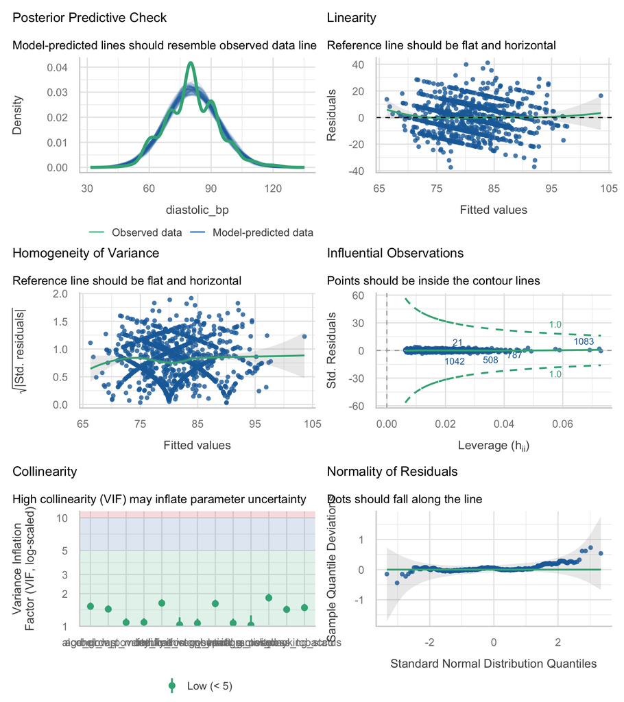

HC3 heteroscedasticity-consistent standard errors

Compared with ordinary least-squares standard errors

| Term | Estimate | SE (OLS) | SE (HC3) | 95% CI (HC3) | p (HC3) |
| --- | --- | --- | --- | --- | --- |
| bmi | 0.940 | 0.082 | 0.082 | 0.78 to 1.10 | <0.001 |
| sexMale | 2.153 | 0.986 | 1.004 | 0.18 to 4.12 | 0.032 |
| age_group60 or more | 5.220 | 1.067 | 1.124 | 3.01 to 7.42 | <0.001 |
| alcohol_last_monthYes | 2.784 | 1.102 | 1.183 | 0.46 to 5.10 | 0.019 |
| smoking_statusFormer | 4.985 | 0.985 | 0.987 | 3.05 to 6.92 | <0.001 |
| salt_g_per_day | 0.079 | 0.149 | 0.144 | -0.20 to 0.36 | 0.582 |

The **posterior-predictive check** shows the model reproducing the bulk of the diastolic distribution but missing the digit-preference spikes at 70, 80 and 90 mmHg that are visible in the raw data: readings were recorded to the nearest whole number by a human operator and cluster on multiples of ten, which no continuous model can reproduce. The **linearity** panel is close to flat. The **homogeneity of variance** panel shows a mild fan, and `check_heteroscedasticity()` flags it at p 0.05 – borderline rather than gross, but flagged. As heteroscedasticity biases standard errors and not coefficients, HC3 robust standard errors are reported above; they are almost identical to the OLS ones (BMI 0.082 versus 0.082), so no substantive conclusion changes, but the robust version is the one to quote. **Collinearity** is not an issue: maximum VIF 1.83, which is only achievable because `systolic_bp`, `mets_min_per_week` and `cigarettes_per_week` were kept out. **Influential observations** shows no point beyond the Cook’s distance contour. **Normality of residuals** shows mild departure at both tails, partly from the digit preference; with 1159 observations this does not threaten the coefficient estimates.

# Discussion

Diastolic blood pressure in these Bharatpur adults is driven by body mass index and, more weakly than systolic pressure, by age. Each kg/m2 of BMI corresponds to about 0.94 mmHg, so the difference between a BMI of 22 and 28 is roughly 5.6 mmHg; being 60 or over rather than in one’s thirties adds about 5 mmHg. Alcohol retains a modest independent association of 2.8 mmHg. Everything else – salt, physical activity, fruit and vegetables, family history, poverty, education, smokeless tobacco – is null once age, sex and BMI are accounted for. Practically, this is another argument that weight is the single actionable target in this population, and a warning that the crude lifestyle associations that make attractive headlines here are mostly demographic confounding.

**Limitations.** The most serious problem is **treatment bias in the outcome**. 131 participants (11.3%) were on antihypertensive medication when measured, so what this file records is diastolic pressure *as currently treated*, and because treatment is concentrated in those with the highest underlying pressure, coefficients for any risk factor that also predicts treatment are attenuated by an unknown amount. The sensitivity analysis bounds this rather than removing it. Second, **the cluster sampling cannot be modelled**: only four wards were randomly selected and about 300 participants enrolled in each, with a design effect of 1.5 assumed in the sample size calculation, but no ward identifier exists in this extract. The confidence intervals reported above are therefore too narrow – plausibly by around 20% – and no mixed or survey-weighted model can repair that. Four clusters also make any claim of representativeness of Nepal, or even of Bharatpur as a whole, unsupportable. Third, **age is available only in four bands**, so no per-year slope is estimable and the top band is open-ended. Fourth, this is cross-sectional, so associations are not causal effects, and the former-smoker coefficient is a live demonstration of reverse causation. Fifth, diastolic readings show clear terminal-digit preference at multiples of ten, which adds measurement noise and slightly distorts the residual distribution. Sixth, salt intake is estimated rather than measured by 24-hour urinary sodium, so its null association may be measurement error rather than biology. Seventh, adjusted R-squared is only 0.178. On the credit side, **the file has no missing data at all**: all 1159 rows are complete on all 21 variables.

**Future work.** Obtain the ward identifier and refit with a random intercept for ward; and repeat the analysis on a bias-corrected outcome that adds a fixed 5-10 mmHg diastolic offset to treated participants.

# Feasibility notes

*Not part of a student report.*